# CDD - Análise das avaliações de séries de TV e Streaming no IMDb

### Para esta análise foram utilizados os dados fornecidos pelo IMDb sobre classificações de séries de TV e Streaming feitas pelo público.

### Informações sobre as variáveis utilizadas e a coleta dos dados podem ser encontradas em: https://github.com/nazareno/imdb-series.

```r
series = read_csv(here("data/series_from_imdb.csv.zip"),
                      col_types = "ccdcdcdddddddddddd")
```

## Qual a variação das notas e dos votos atribuidos pelos usuários na série Sobrenatural?

*Para esta pergunta foram analisadas as notas e os votos dos usuários de cada episódio a partir da sétima temporada de Sobrenatural, as temporadas anteriores(1 à 6) não foram disponilibizadas nos dados originais.*

```r
avaliacao = series %>%
    filter(series_name == "Sobrenatural")
```

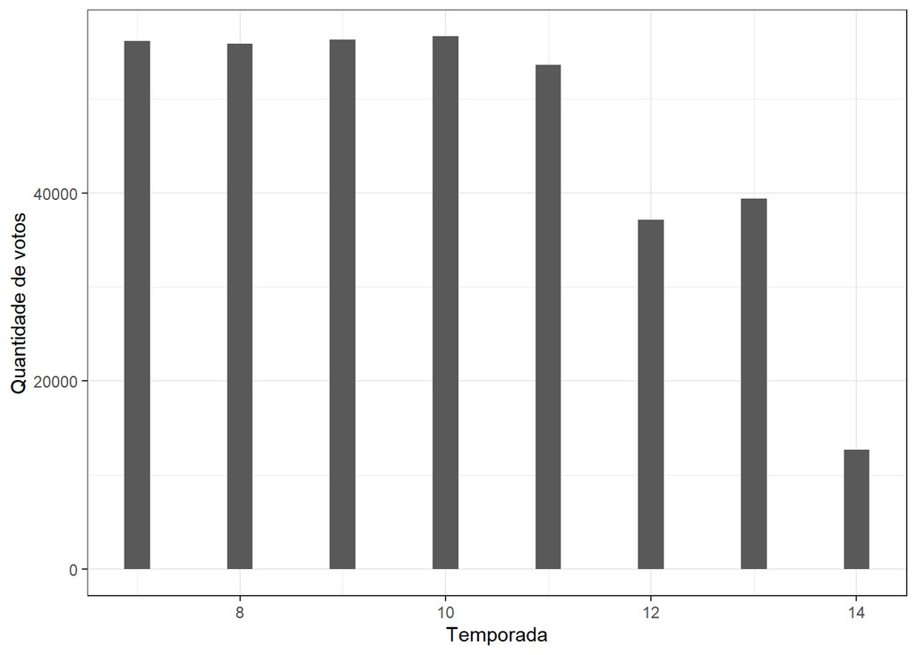

```r
avaliacao %>%
    select(season, UserVotes)%>%
    mutate(season = as.integer(season))%>%
    ggplot(mapping = aes(x = season, y = UserVotes))+
    geom_bar(stat = "identity", width = 0.25)+
    labs(
        x = "Temporada",
        y = "Quantidade de votos"
    )
```

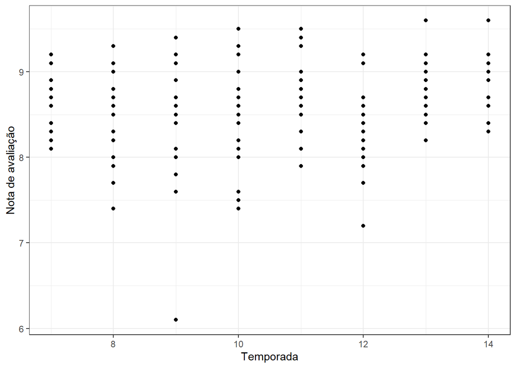

```r
avaliacao %>%
    select(season, UserRating)%>%
    mutate(season = as.integer(season))%>%
    ggplot(mapping = aes(x = season, y = UserRating))+
    geom_point() +
    labs(
         x = "Temporada",
         y = "Nota de avaliação"
    )
```

**Para a variação das notas, nota-se que a 9ª temporada foi a única que obteve uma avaliação menor que 7. As demais temporadas obtiveram notas entre valores maiores que 7 e menores que 10, com alguns pontos extremos. A temporada que teve uma menor variação das notas foi a 7ª.**

## Quais temporadas de Sobrenatural receberam a maior média nas avaliações?

*Para responder esta pergunta foram calculadas as médias das notas dos episódios a partir dos dados originais.*

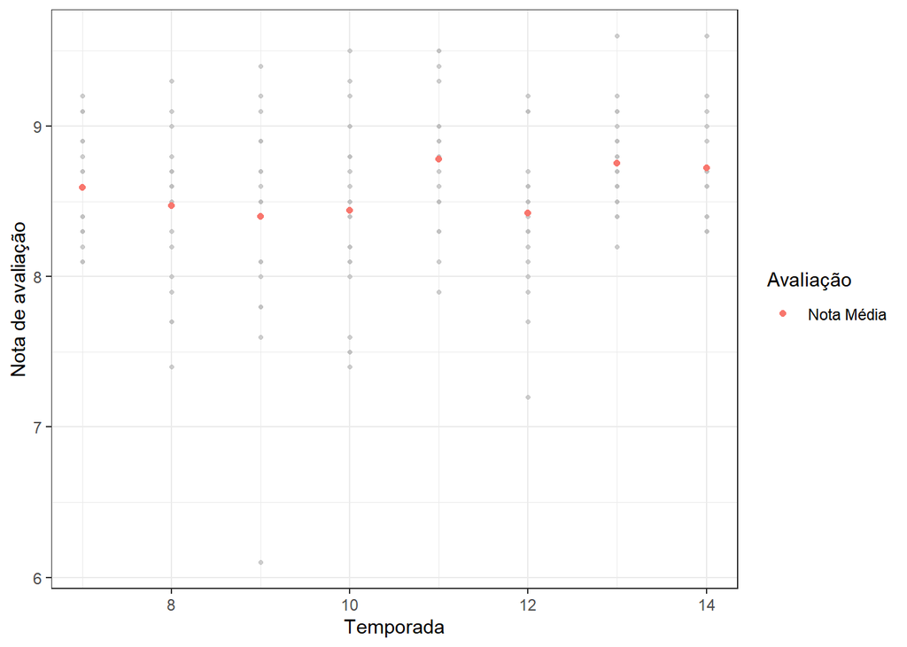

```r
sumario = avaliacao %>%
    group_by(season)%>%
    mutate(season = as.integer(season))%>%
    summarise(nota_media = mean(UserRating),
              .groups = "drop")

avaliacao %>%
    select(season, UserRating)%>%
    mutate(season = as.integer(season))%>%
    ggplot(mapping = aes(x = season, y = UserRating))+
    geom_point(alpha = .75, size = .9, color = "grey") +
    geom_point(data = sumario, aes(y = nota_media, colour = "Nota Média"))+

    labs(
        x = "Temporada",
        y = "Nota de avaliação",
        color = "Avaliação"
    )
```

```r
sumario%>%
      select(season, nota_media)
```

```
## # A tibble: 8 x 2
##   season nota_media
##    <int>      <dbl>
## 1      7       8.59
## 2      8       8.47
## 3      9       8.4
## 4     10       8.44
## 5     11       8.78
## 6     12       8.42
## 7     13       8.75
## 8     14       8.72
```

**Observa-se que a temporada que obteve maior média foi a 11ª, e a que obteve a menor média foi a 9ª.**

## Existe alguma relação entre a quantidade de votos e a nota de avaliação dos episódios de Sobrenatural?

*Para esta pergunta foram analisadas as quantidades de votos e as notas de avaliação de cada episodio de todas as temporadas disponíveis.*

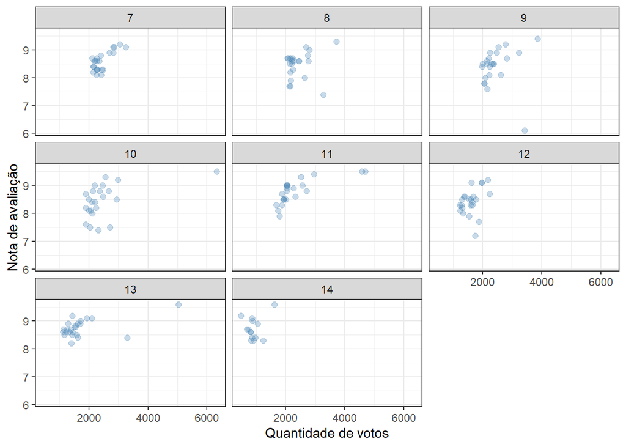

```r
avaliacao %>%
    mutate(season = as.integer(season))%>%
    ggplot(aes(x = UserVotes, y = UserRating)) +
    facet_wrap(~ season) +
    geom_point(alpha = .3, size = 2, colour="steelblue") +
    labs(
        y = "Nota de avaliação",
        x = "Quantidade de votos"
    )
```

**É possível observar que algumas temporadas apresentam um padrão linear com uma correlação positiva e com intensidade relativamente alta entre a quantidade de votos de um episódio e sua nota, porém em outras temporadas este padrão não é tão visível.**

```r
avaliacao %>%
   group_by(season) %>%
   mutate(season = as.integer(season))%>%
   summarise(pearson = cor(UserRating, UserVotes,
                              method = "pearson"),
              .groups = "drop")
```

```
## # A tibble: 8 x 2
##   season pearson
##    <int>   <dbl>
## 1      7  0.748
## 2      8  0.207
## 3      9  0.0726
## 4     10  0.482
## 5     11  0.729
## 6     12  0.363
## 7     13  0.515
## 8     14  0.252
```

**Analisando-se o coeficiente de correlação de Pearson é possível notar que de fato, existe uma correlação positiva entre as notas e a quantidade de votos dos episódios de Sobrenatural, sendo as mais altas nas temporadas 7 e 11.**